# data.table how does it work

```r
library (data.table)
```

## General form

The general form of a `data.table` query is `[i, j, by]`. The 3 parts of the query can be mapped to SQL as *i* = where, *j* = select, and *by* = group by.

```r
mtcarsDT <- data.table (mtcars)
mtcarsDT
```

```
##      mpg cyl  disp  hp drat    wt  qsec vs am gear carb
##  1: 21.0   6 160.0 110 3.90 2.620 16.46  0  1    4    4
##  2: 21.0   6 160.0 110 3.90 2.875 17.02  0  1    4    4
##  3: 22.8   4 108.0  93 3.85 2.320 18.61  1  1    4    1
##  4: 21.4   6 258.0 110 3.08 3.215 19.44  1  0    3    1
##  5: 18.7   8 360.0 175 3.15 3.440 17.02  0  0    3    2
##  6: 18.1   6 225.0 105 2.76 3.460 20.22  1  0    3    1
##  7: 14.3   8 360.0 245 3.21 3.570 15.84  0  0    3    4
##  8: 24.4   4 146.7  62 3.69 3.190 20.00  1  0    4    2
##  9: 22.8   4 140.8  95 3.92 3.150 22.90  1  0    4    2
## 10: 19.2   6 167.6 123 3.92 3.440 18.30  1  0    4    4
## 11: 17.8   6 167.6 123 3.92 3.440 18.90  1  0    4    4
## 12: 16.4   8 275.8 180 3.07 4.070 17.40  0  0    3    3
## 13: 17.3   8 275.8 180 3.07 3.730 17.60  0  0    3    3
## 14: 15.2   8 275.8 180 3.07 3.780 18.00  0  0    3    3
```

[output cut: 19 more lines]

```r
mtcarsDT [mpg > 20,
          .(AvgHP = mean(hp),
            "minWT(kg)" = min (wt + 453.6)), # wt in lbs
          by = .(cyl, under5gears = gear < 5)]
```

```
##    cyl under5gears     AvgHP minWT(kg)
## 1:   6        TRUE 110.00000   456.220
## 2:   4        TRUE  78.33333   455.215
## 3:   4       FALSE 102.00000   455.113
```

> Take DT, subset rows using *i*, then calculate *j* grouped by *by*

In creation of a `data.table`, use `L` after a numeric to specify that it is an integer (NOT *numeric*). Give columns with different lengths, and R will “recycle” the shorter column to match the length of the longer one by re-using the first items

```r
## Create a data.table
## Column a will be of integer type
DT <- data.table(a = c(1L, 2L), b = LETTERS[1:4])

## Create another data.table
## Columns B and C will be cycling
DT <- data.table (A = 1:6, B = c("a", "b", "c"), C = rnorm (6), D = TRUE)
```

## Selecting rows by number in *i*

```r
DT [3:5,]
```

```
##    A B          C    D
## 1: 3 c -2.2805453 TRUE
## 2: 4 a -0.1179344 TRUE
## 3: 5 b -1.5610129 TRUE
```

```r
DT [3:5] # same thing, unlike data.frame
```

```
##    A B          C    D
## 1: 3 c -2.2805453 TRUE
## 2: 4 a -0.1179344 TRUE
## 3: 5 b -1.5610129 TRUE
```

## Compatibility

`data.table` is a `data.frame` too. It is accepted by all base R packages.

```r
class (DT)
```

```
## [1] "data.table" "data.frame"
```

When a `data.table` is called by a function, it looks to see where it is called from. When it is called by a package which does not recognize `data.table`, it will switch `data.frame`, and it will still work.

The `.N` in `data.table` means number of rows

```r
DT [.N]
```

```
##    A B          C    D
## 1: 6 c -0.7767423 TRUE
```

```r
DT [nrow(DT)] # same thing
```

```
##    A B          C    D
## 1: 6 c -0.7767423 TRUE
```

```r
# Select the second to last row
DT [.N-1]
```

```
##    A B         C    D
## 1: 5 b -1.561013 TRUE
```

```r
# Names and dimensions
names (DT)
```

```
## [1] "A" "B" "C" "D"
```

```r
dim (DT)
```

```
## [1] 6 4
```

```r
# Selective subsetting
DT [c (2, 2, 3)]
```

```
##    A B          C    D
## 1: 2 b -0.9904338 TRUE
## 2: 2 b -0.9904338 TRUE
## 3: 3 c -2.2805453 TRUE
```

## Sececting columns in *j*

```r
DT [, .(B, C)] # .() is an alias to list() in data.tables and they mean the same
```

```
##    B          C
## 1: a  0.8641541
## 2: b -0.9904338
## 3: c -2.2805453
## 4: a -0.1179344
## 5: b -1.5610129
## 6: c -0.7767423
```

```r
DT [c(1, 3), .(B, C)] # a vector is required for i
```

```
##    B          C
## 1: a  0.8641541
## 2: c -2.2805453
```

```r
# Object or Column names?
B <- 3
DT [, .(B)]
```

```
##    B
## 1: a
## 2: b
## 3: c
## 4: a
## 5: b
## 6: c
```

```r
DT [, B]
```

```
## [1] "a" "b" "c" "a" "b" "c"
```

## Computing on columns

Call functions on the columns as if the columns were variables. We can provide new column names while computing. If we don’t, column names will be assigned automatically.

```r
DT [, .(Total = sum(A), Mean = mean(C))]
```

```
##    Total       Mean
## 1:    21 -0.8104191
```

```r
# No column names
DT [, .(sum(A), mean(C))]
```

```
##    V1         V2
## 1: 21 -0.8104191
```

## Recying in *j*

```r
# The value of C will be recycled to fit the length of B
DT [, .(B, C = sum (C))]
```

```
##    B         C
## 1: a -4.862515
## 2: b -4.862515
## 3: c -4.862515
## 4: a -4.862515
## 5: b -4.862515
## 6: c -4.862515
```

## Throw anything into J

without even giving a value

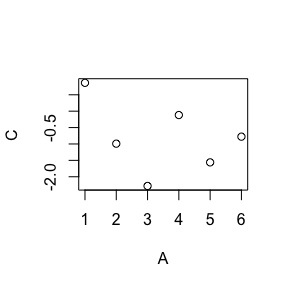

```r
# A plot and a Null value will be returned
DT [, plot (A, C)]
```

Throw multiple actions in curly brackets

```
## [1] 1 2 3 4 5 6
```

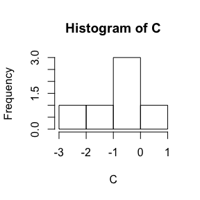

```r
DT [, {print(A)
  hist(C)
  NULL}] # set NULL to plot C instead of counting C values
```

## Doing *j* by group

```r
# the groups are returned in order as they appear in the original DT
DT [, .(mySum = sum(A),
        myMean = mean(A)),
    by = .(B)]
```

```
##    B mySum myMean
## 1: a     5    2.5
## 2: b     7    3.5
## 3: c     9    4.5
```

## Function calls in *by*

```r
DT [, .(mySum = sum(C)), by = .(Grp = A%%2)]
```

```
##    Grp     mySum
## 1:   1 -2.977404
## 2:   0 -1.885111
```

```r
# if you just have one items each, you can do this:
DT [, sum(C), by = A%%2]
```

```
##    A        V1
## 1: 1 -2.977404
## 2: 0 -1.885111
```

## Grouping only on the subset

```r
# Note that the even numbers return first because of the selection
DT [2:4, sum(C), by = A%%2]
```

```
##    A        V1
## 1: 0 -1.108368
## 2: 1 -2.280545
```

## Practice using iris

```r
DT <- data.table (iris)
head (DT)
```

```
##    Sepal.Length Sepal.Width Petal.Length Petal.Width Species
## 1:          5.1         3.5          1.4         0.2  setosa
## 2:          4.9         3.0          1.4         0.2  setosa
## 3:          4.7         3.2          1.3         0.2  setosa
## 4:          4.6         3.1          1.5         0.2  setosa
## 5:          5.0         3.6          1.4         0.2  setosa
## 6:          5.4         3.9          1.7         0.4  setosa
```

```r
DT [, mean (Sepal.Length), by = Species]
```

```
##       Species    V1
## 1:     setosa 5.006
## 2: versicolor 5.936
## 3:  virginica 6.588
```

```r
DT [, mean (Sepal.Length), by = .(substr (Species, 1, 1))]
```

```
##    substr    V1
## 1:      s 5.006
## 2:      v 6.262
```

```r
# .N in j
DT [, .(Count = .N), by = .(Area = round (Sepal.Length* Sepal.Width /10))]
```

```
##    Area Count
## 1:    2   117
## 2:    1    29
## 3:    3     4
```

## Grouping by multiple columns

```r
DT [, .(C = cumsum (Sepal.Length)), .(Petal.Width, Species)]
```

```
##      Petal.Width   Species    C
##   1:         0.2    setosa  5.1
##   2:         0.2    setosa 10.0
##   3:         0.2    setosa 14.7
##   4:         0.2    setosa 19.3
##   5:         0.2    setosa 24.3
##  ---
## 146:         2.3 virginica 55.3
## 147:         1.5 virginica  6.0
## 148:         1.5 virginica 12.3
## 149:         1.6 virginica  7.2
## 150:         1.4 virginica  6.1
```

```r
DT [, .(C = tail (Sepal.Length, 2)), by = .(Species)]
```

```
##       Species   C
## 1:     setosa 5.3
## 2:     setosa 5.0
## 3: versicolor 5.1
## 4: versicolor 5.7
## 5:  virginica 6.2
## 6:  virginica 5.9
```

## Chaining operations together

```r
# in multiple statements
DT <- data.table (A = c("c", "b", "a"), B = 1:6)
DT
```

```
##    A B
## 1: c 1
## 2: b 2
## 3: a 3
## 4: c 4
## 5: b 5
## 6: a 6
```

```r
ans <- DT [, sum (B), by = A]
ans
```

```
##    A V1
## 1: c  5
## 2: b  7
## 3: a  9
```

```r
ans [order (A)]
```

```
##    A V1
## 1: a  9
## 2: b  7
## 3: c  5
```

```r
# in one sigle single statement
DT [, sum (B), by = A] [order (A)]
```

```
##    A V1
## 1: a  9
## 2: b  7
## 3: c  5
```

## Chaining the previous iris example

```r
DT <- data.table (iris)
DT [, .(C = cumsum (Sepal.Length)), .(Petal.Width, Species)][, .(C = tail (C, 2)), by = .(Species)]
```

```
##       Species    C
## 1:     setosa  5.1
## 2:     setosa  5.0
## 3: versicolor 28.9
## 4: versicolor  6.7
## 5:  virginica  7.2
## 6:  virginica  6.1
```

```r
DT [, .(Sepal.Length = median (Sepal.Length),
       Sepal.Width = median (Sepal.Width),
       Petal.Length = median (Petal.Length),
       Petal.Width = median (Petal.Width)),
    by = Species] [order (Species, decreasing = TRUE)]
```

```
##       Species Sepal.Length Sepal.Width Petal.Length Petal.Width
## 1:  virginica          6.5         3.0         5.55         2.0
## 2: versicolor          5.9         2.8         4.35         1.3
## 3:     setosa          5.0         3.4         1.50         0.2
```

## Subset of data: .SD

When you have too many columns and you want to perform particular operation on a subset of columns

```r
# .SD represents all columns except those specified in by
DT [, lapply (.SD, median), by = Species]
```

```
##       Species Sepal.Length Sepal.Width Petal.Length Petal.Width
## 1:     setosa          5.0         3.4         1.50         0.2
## 2: versicolor          5.9         2.8         4.35         1.3
## 3:  virginica          6.5         3.0         5.55         2.0
```

```r
# .SDcols specifies columns used in .SD
DT [, lapply(.SD, sum), .SDcols =2:4]
```

```
##    Sepal.Width Petal.Length Petal.Width
## 1:       458.6        563.7       179.9
```

```r
# select all but first row of the groups
DT <- data.table (A = c("c", "c", "b", "a"), B = 1:6, C = TRUE, D = 5L)
DT
```

```
##    A B    C D
## 1: c 1 TRUE 5
## 2: c 2 TRUE 5
## 3: b 3 TRUE 5
## 4: a 4 TRUE 5
## 5: c 5 TRUE 5
## 6: c 6 TRUE 5
```

```r
DT [, .SD[-1], .SDcols = 2:4, by = A]
```

```
##    A B    C D
## 1: c 2 TRUE 5
## 2: c 5 TRUE 5
## 3: c 6 TRUE 5
```

```r
# sum all cols and number of rows
DT <- data.table (x = c(2,1,2,1,2,2,1),
                  y = c(1,3,5,7,9,11,13),
                  z = c(2,4,6,8,10,12,14))
DT [, c (lapply (.SD, sum), .N), by = x, .SDcols = c ("x", "y", "z")]
```

```
##    x x  y  z N
## 1: 2 8 26 30 4
## 2: 1 3 23 26 3
```

```r
# cumsum while grouping
DT [, lapply (.SD, cumsum), .SDcols = 1:2, by = .(by1 = x, by2 = z > 8)]
```

```
##    by1   by2 x  y
## 1:   2 FALSE 2  1
## 2:   2 FALSE 4  6
## 3:   1 FALSE 1  3
## 4:   1 FALSE 2 10
## 5:   2  TRUE 2  9
## 6:   2  TRUE 4 20
## 7:   1  TRUE 1 13
```

## Add/update columns in *j* using :=

```r
DT
```

```
##    x  y  z
## 1: 2  1  2
## 2: 1  3  4
## 3: 2  5  6
## 4: 1  7  8
## 5: 2  9 10
## 6: 2 11 12
## 7: 1 13 14
```

```r
# Add
DT [, c("x", "p") := .(rev(x), 1:7)]
DT
```

```
##    x  y  z p
## 1: 1  1  2 1
## 2: 2  3  4 2
## 3: 2  5  6 3
## 4: 1  7  8 4
## 5: 2  9 10 5
## 6: 1 11 12 6
## 7: 2 13 14 7
```

```r
DT [, x := rev(x)] # short expression
DT
```

```
##    x  y  z p
## 1: 2  1  2 1
## 2: 1  3  4 2
## 3: 2  5  6 3
## 4: 1  7  8 4
## 5: 2  9 10 5
## 6: 2 11 12 6
## 7: 1 13 14 7
```

```r
# Remove
DT [, c("y", "z") := NULL]
DT [, z := NULL] # short expression
DT
```

```
##    x p
## 1: 2 1
## 2: 1 2
## 3: 2 3
## 4: 1 4
## 5: 2 5
## 6: 2 6
## 7: 1 7
```

```r
# use objects
myCol <- c ("x", "p")
DT [, (myCol) := .(rev(x), 1:7)] # wrap in (), or it's recognized as column names
DT
```

```
##    x p
## 1: 1 1
## 2: 2 2
## 3: 2 3
## 4: 1 4
## 5: 2 5
## 6: 1 6
## 7: 2 7
```

```r
# assign multiple columns
DT [, ":=" (y = x*2,
            q = p+1)]
DT
```

```
##    x p y q
## 1: 1 1 2 2
## 2: 2 2 4 3
## 3: 2 3 4 4
## 4: 1 4 2 5
## 5: 2 5 4 6
## 6: 1 6 2 7
## 7: 2 7 4 8
```

## := cimbined with *i* and *by*

```r
DT <- data.table (x = c (2, 2, 1, 1, 1), y = 6:10)
DT [2:4, z := sum (y), by = x]
DT
```

```
##    x  y  z
## 1: 2  6 NA
## 2: 2  7  7
## 3: 1  8 17
## 4: 1  9 17
## 5: 1 10 NA
```

## Add/update multiple columns

```r
DT <- data.table (A = c(1, 1, 1, 2, 2), B = 1:5)
DT [,":="(B = B + 1, C = A + B, D = 2)]
DT
```

```
##    A B C D
## 1: 1 2 2 2
## 2: 1 3 3 2
## 3: 1 4 4 2
## 4: 2 5 6 2
## 5: 2 6 7 2
```

## Delete by col number

```r
DT [, 2 := NULL]
DT
```

```
##    A C D
## 1: 1 2 2
## 2: 1 3 2
## 3: 1 4 2
## 4: 2 6 2
## 5: 2 7 2
```

## set()

repeated update data by reference

```r
DT <- data.table (x = 1:5, y = c (1, 8, 1, 1, 1), z = c (2, 5, 4, 2, 3))
# update the 1:5 rows of the 3rd column into new values
for (i in 1:5) DT [i, z := i + 1]
for (i in 1:5) set (DT, i, 3L, i + 1) # a better way
DT

# set random 3 rows to NA
for (i in 2:3) set(DT, sample(1:5, 3), i, NA)
DT
```

```
##    x  y  z
## 1: 1  1  2
## 2: 2  8  3
## 3: 3 NA NA
## 4: 4 NA NA
## 5: 5 NA NA
```

## setnames()

```r
setnames (DT, "z", "p")
DT
```

```
##    x  y  p
## 1: 1  1  2
## 2: 2  8  3
## 3: 3 NA NA
## 4: 4 NA NA
## 5: 5 NA NA
```

```r
setnames (DT, names (DT), toupper (names(DT)))
DT
```

```
##    X  Y  P
## 1: 1  1  2
## 2: 2  8  3
## 3: 3 NA NA
## 4: 4 NA NA
## 5: 5 NA NA
```

## setcolorder()

```r
setcolorder (DT, c("P", "X", "Y"))
DT
```

```
##     P X  Y
## 1:  2 1  1
## 2:  3 2  8
## 3: NA 3 NA
## 4: NA 4 NA
## 5: NA 5 NA
```

## The `set` family

```r
setnames (DT, names (DT), paste0 (names (DT), "_2"))
DT
```

```
##    P_2 X_2 Y_2
## 1:   2   1   1
## 2:   3   2   8
## 3:  NA   3  NA
## 4:  NA   4  NA
## 5:  NA   5  NA
```

```r
setcolorder (DT, rev (names (DT)))
DT
```

```
##    Y_2 X_2 P_2
## 1:   1   1   2
## 2:   8   2   3
## 3:  NA   3  NA
## 4:  NA   4  NA
## 5:  NA   5  NA
```

## Using column names in i

```r
DT <- data.table (A = c("c", "b", "a"), B = 1:6)
DT
```

```
##    A B
## 1: c 1
## 2: b 2
## 3: a 3
## 4: c 4
## 5: b 5
## 6: a 6
```

```r
DT [A == "a"]
```

```
##    A B
## 1: a 3
## 2: a 6
```

```r
DT [A %in% c ("a", "c")]
```

```
##    A B
## 1: c 1
## 2: a 3
## 3: c 4
## 4: a 6
```

```r
# Indexing
w <- DT [, A == "a"] # return a vector if not wrapped in .()
w
```

```
## [1] FALSE FALSE  TRUE FALSE FALSE  TRUE
```

```r
DT [w]
```

```
##    A B
## 1: a 3
## 2: a 6
```

## Indexing using iris

```r
DT <- data.table(iris)

# Species is "virginica"
DT [Species == "virginica"]
```

```
##     Sepal.Length Sepal.Width Petal.Length Petal.Width   Species
##  1:          6.3         3.3          6.0         2.5 virginica
##  2:          5.8         2.7          5.1         1.9 virginica
##  3:          7.1         3.0          5.9         2.1 virginica
##  4:          6.3         2.9          5.6         1.8 virginica
##  5:          6.5         3.0          5.8         2.2 virginica
##  6:          7.6         3.0          6.6         2.1 virginica
##  7:          4.9         2.5          4.5         1.7 virginica
##  8:          7.3         2.9          6.3         1.8 virginica
##  9:          6.7         2.5          5.8         1.8 virginica
## 10:          7.2         3.6          6.1         2.5 virginica
## 11:          6.5         3.2          5.1         2.0 virginica
## 12:          6.4         2.7          5.3         1.9 virginica
## 13:          6.8         3.0          5.5         2.1 virginica
## 14:          5.7         2.5          5.0         2.0 virginica
```

[output cut: 37 more lines]

```r
# Species is either "virginica" or "versicolor"
DT [Species %in% c("virginica", "versicolor")]
```

```
##      Sepal.Length Sepal.Width Petal.Length Petal.Width    Species
##   1:          7.0         3.2          4.7         1.4 versicolor
##   2:          6.4         3.2          4.5         1.5 versicolor
##   3:          6.9         3.1          4.9         1.5 versicolor
##   4:          5.5         2.3          4.0         1.3 versicolor
##   5:          6.5         2.8          4.6         1.5 versicolor
##   6:          5.7         2.8          4.5         1.3 versicolor
##   7:          6.3         3.3          4.7         1.6 versicolor
##   8:          4.9         2.4          3.3         1.0 versicolor
##   9:          6.6         2.9          4.6         1.3 versicolor
##  10:          5.2         2.7          3.9         1.4 versicolor
##  11:          5.0         2.0          3.5         1.0 versicolor
##  12:          5.9         3.0          4.2         1.5 versicolor
##  13:          6.0         2.2          4.0         1.0 versicolor
##  14:          6.1         2.9          4.7         1.4 versicolor
```

[output cut: 87 more lines]

```r
# Remove the "Sepal." prefix
setnames (DT, gsub("^Sepal\\.", "", names (DT)))
DT
```

```
##      Length Width Petal.Length Petal.Width   Species
##   1:    5.1   3.5          1.4         0.2    setosa
##   2:    4.9   3.0          1.4         0.2    setosa
##   3:    4.7   3.2          1.3         0.2    setosa
##   4:    4.6   3.1          1.5         0.2    setosa
##   5:    5.0   3.6          1.4         0.2    setosa
##  ---
## 146:    6.7   3.0          5.2         2.3 virginica
## 147:    6.3   2.5          5.0         1.9 virginica
## 148:    6.5   3.0          5.2         2.0 virginica
## 149:    6.2   3.4          5.4         2.3 virginica
## 150:    5.9   3.0          5.1         1.8 virginica
```

```r
# Remove the two columns starting with "Petal"
DT [, grep ("^Petal", names (DT)) := NULL]
DT
```

```
##      Length Width   Species
##   1:    5.1   3.5    setosa
##   2:    4.9   3.0    setosa
##   3:    4.7   3.2    setosa
##   4:    4.6   3.1    setosa
##   5:    5.0   3.6    setosa
##  ---
## 146:    6.7   3.0 virginica
## 147:    6.3   2.5 virginica
## 148:    6.5   3.0 virginica
## 149:    6.2   3.4 virginica
## 150:    5.9   3.0 virginica
```

## Automatic indexing

“if i is a single variable name, it is evaluated in the calling scope, otherwise inside DT’s scope” Only single columns on the left side of operators benefit from automatic indexing.

```r
# Cleaned up iris data.table
DT <- data.table(iris)

# Area is greater than 20 square centimeters
DT [ Sepal.Width * Sepal.Length > 20 ]
```

```
##     Sepal.Length Sepal.Width Petal.Length Petal.Width    Species
##  1:          5.4         3.9          1.7         0.4     setosa
##  2:          5.8         4.0          1.2         0.2     setosa
##  3:          5.7         4.4          1.5         0.4     setosa
##  4:          5.4         3.9          1.3         0.4     setosa
##  5:          5.7         3.8          1.7         0.3     setosa
##  6:          5.2         4.1          1.5         0.1     setosa
##  7:          5.5         4.2          1.4         0.2     setosa
##  8:          7.0         3.2          4.7         1.4 versicolor
##  9:          6.4         3.2          4.5         1.5 versicolor
## 10:          6.9         3.1          4.9         1.5 versicolor
## 11:          6.3         3.3          4.7         1.6 versicolor
## 12:          6.7         3.1          4.4         1.4 versicolor
## 13:          6.7         3.0          5.0         1.7 versicolor
## 14:          6.0         3.4          4.5         1.6 versicolor
```

[output cut: 28 more lines]

```r
# Add new boolean column
DT [, is_large := Sepal.Width * Sepal.Length > 25]
DT
```

```
##      Sepal.Length Sepal.Width Petal.Length Petal.Width   Species is_large
##   1:          5.1         3.5          1.4         0.2    setosa    FALSE
##   2:          4.9         3.0          1.4         0.2    setosa    FALSE
##   3:          4.7         3.2          1.3         0.2    setosa    FALSE
##   4:          4.6         3.1          1.5         0.2    setosa    FALSE
##   5:          5.0         3.6          1.4         0.2    setosa    FALSE
##  ---
## 146:          6.7         3.0          5.2         2.3 virginica    FALSE
## 147:          6.3         2.5          5.0         1.9 virginica    FALSE
## 148:          6.5         3.0          5.2         2.0 virginica    FALSE
## 149:          6.2         3.4          5.4         2.3 virginica    FALSE
## 150:          5.9         3.0          5.1         1.8 virginica    FALSE
```

```r
# Now large observations with is_large
DT [is_large == TRUE]
```

```
##    Sepal.Length Sepal.Width Petal.Length Petal.Width   Species is_large
## 1:          5.7         4.4          1.5         0.4    setosa     TRUE
## 2:          7.2         3.6          6.1         2.5 virginica     TRUE
## 3:          7.7         3.8          6.7         2.2 virginica     TRUE
## 4:          7.9         3.8          6.4         2.0 virginica     TRUE
```

```r
DT [(is_large)] # Also OK
```

```
##    Sepal.Length Sepal.Width Petal.Length Petal.Width   Species is_large
## 1:          5.7         4.4          1.5         0.4    setosa     TRUE
## 2:          7.2         3.6          6.1         2.5 virginica     TRUE
## 3:          7.7         3.8          6.7         2.2 virginica     TRUE
## 4:          7.9         3.8          6.4         2.0 virginica     TRUE
```

## Creating and using a key

When a key is being set, the data.table sorts the data by the column we specify and change the table by reference. Having set a key will allow you to use it, for example, as a super-charged row name when doing selections.

```r
DT <- data.table (iris [c(101:103, 51:53, 1:3),])
DT
```

```
##    Sepal.Length Sepal.Width Petal.Length Petal.Width    Species
## 1:          6.3         3.3          6.0         2.5  virginica
## 2:          5.8         2.7          5.1         1.9  virginica
## 3:          7.1         3.0          5.9         2.1  virginica
## 4:          7.0         3.2          4.7         1.4 versicolor
## 5:          6.4         3.2          4.5         1.5 versicolor
## 6:          6.9         3.1          4.9         1.5 versicolor
## 7:          5.1         3.5          1.4         0.2     setosa
## 8:          4.9         3.0          1.4         0.2     setosa
## 9:          4.7         3.2          1.3         0.2     setosa
```

```r
setkey (DT, Species)
DT
```

```
##    Sepal.Length Sepal.Width Petal.Length Petal.Width    Species
## 1:          5.1         3.5          1.4         0.2     setosa
## 2:          4.9         3.0          1.4         0.2     setosa
## 3:          4.7         3.2          1.3         0.2     setosa
## 4:          7.0         3.2          4.7         1.4 versicolor
## 5:          6.4         3.2          4.5         1.5 versicolor
## 6:          6.9         3.1          4.9         1.5 versicolor
## 7:          6.3         3.3          6.0         2.5  virginica
## 8:          5.8         2.7          5.1         1.9  virginica
## 9:          7.1         3.0          5.9         2.1  virginica
```

```r
# indexing
DT ["setosa"]
```

```
##    Sepal.Length Sepal.Width Petal.Length Petal.Width Species
## 1:          5.1         3.5          1.4         0.2  setosa
## 2:          4.9         3.0          1.4         0.2  setosa
## 3:          4.7         3.2          1.3         0.2  setosa
```

```r
# Arguments like mult and nomatch then help you to select only particular parts of groups.
DT ["setosa", mult = "first"] # the first row of selection
```

```
##    Sepal.Length Sepal.Width Petal.Length Petal.Width Species
## 1:          5.1         3.5          1.4         0.2  setosa
```

```r
DT ["setosa", mult = "last"] # the last row of selection
```

```
##    Sepal.Length Sepal.Width Petal.Length Petal.Width Species
## 1:          4.7         3.2          1.3         0.2  setosa
```

```r
# Indexing with no match item
DT [c ("setosa", "gropa")] # default is nomatch = NA
```

```
##    Sepal.Length Sepal.Width Petal.Length Petal.Width Species
## 1:          5.1         3.5          1.4         0.2  setosa
## 2:          4.9         3.0          1.4         0.2  setosa
## 3:          4.7         3.2          1.3         0.2  setosa
## 4:           NA          NA           NA          NA   gropa
```

```r
DT [c ("setosa", "gropa"), nomatch = 0]
```

```
##    Sepal.Length Sepal.Width Petal.Length Petal.Width Species
## 1:          5.1         3.5          1.4         0.2  setosa
## 2:          4.9         3.0          1.4         0.2  setosa
## 3:          4.7         3.2          1.3         0.2  setosa
```

## Two-column key

The second key is sorted within each group of the first key

```r
setkey (DT, Species, Sepal.Length)
DT
```

```
##    Sepal.Length Sepal.Width Petal.Length Petal.Width    Species
## 1:          4.7         3.2          1.3         0.2     setosa
## 2:          4.9         3.0          1.4         0.2     setosa
## 3:          5.1         3.5          1.4         0.2     setosa
## 4:          6.4         3.2          4.5         1.5 versicolor
## 5:          6.9         3.1          4.9         1.5 versicolor
## 6:          7.0         3.2          4.7         1.4 versicolor
## 7:          5.8         2.7          5.1         1.9  virginica
## 8:          6.3         3.3          6.0         2.5  virginica
## 9:          7.1         3.0          5.9         2.1  virginica
```

```r
# indexing both keys
DT [.("setosa", 4.7)]
```

```
##    Sepal.Length Sepal.Width Petal.Length Petal.Width Species
## 1:          4.7         3.2          1.3         0.2  setosa
```

```r
# indexing with no match item
DT [.("setosa", 5.2)]
```

```
##    Sepal.Length Sepal.Width Petal.Length Petal.Width Species
## 1:          5.2          NA           NA          NA  setosa
```

```r
# indexing with only the first key
DT [.("setosa")]
```

```
##    Sepal.Length Sepal.Width Petal.Length Petal.Width Species
## 1:          4.7         3.2          1.3         0.2  setosa
## 2:          4.9         3.0          1.4         0.2  setosa
## 3:          5.1         3.5          1.4         0.2  setosa
```

## See the difference of indexing with and without a key

```r
DT <- data.table (iris [c (101:103, 51:53, 1:3),])
DT
```

```
##    Sepal.Length Sepal.Width Petal.Length Petal.Width    Species
## 1:          6.3         3.3          6.0         2.5  virginica
## 2:          5.8         2.7          5.1         1.9  virginica
## 3:          7.1         3.0          5.9         2.1  virginica
## 4:          7.0         3.2          4.7         1.4 versicolor
## 5:          6.4         3.2          4.5         1.5 versicolor
## 6:          6.9         3.1          4.9         1.5 versicolor
## 7:          5.1         3.5          1.4         0.2     setosa
## 8:          4.9         3.0          1.4         0.2     setosa
## 9:          4.7         3.2          1.3         0.2     setosa
```

```r
DT [Species == "setosa"] # without key
```

```
##    Sepal.Length Sepal.Width Petal.Length Petal.Width Species
## 1:          5.1         3.5          1.4         0.2  setosa
## 2:          4.9         3.0          1.4         0.2  setosa
## 3:          4.7         3.2          1.3         0.2  setosa
```

```r
setkey (DT, Species)
DT ["setosa"] # with key
```

```
##    Sepal.Length Sepal.Width Petal.Length Petal.Width Species
## 1:          5.1         3.5          1.4         0.2  setosa
## 2:          4.9         3.0          1.4         0.2  setosa
## 3:          4.7         3.2          1.3         0.2  setosa
```

## Selecting groups or parts of groups

```r
# The 'keyed' data.table DT
DT <- data.table(A = letters[c(2, 1, 2, 3, 1, 2, 3)],
                 B = c(5, 4, 1, 9, 8, 8, 6),
                 C = 6:12)
setkey(DT, A, B)

# Select the "b" group
DT ["b"]
```

```
##    A B  C
## 1: b 1  8
## 2: b 5  6
## 3: b 8 11
```

```r
# "b" and "c" groups
DT [c ("b", "c")]
```

```
##    A B  C
## 1: b 1  8
## 2: b 5  6
## 3: b 8 11
## 4: c 6 12
## 5: c 9  9
```

```r
# The first row of the "b" and "c" groups
DT [c ("b", "c"), mult = "first"]
```

```
##    A B  C
## 1: b 1  8
## 2: c 6 12
```

```r
# First and last row of the "b" and "c" groups
DT [c ("b", "c"), .SD[c(1, .N)], by = .EACHI]
```

```
##    A B  C
## 1: b 1  8
## 2: b 8 11
## 3: c 6 12
## 4: c 9  9
```

```r
# Copy and extend code for instruction 4: add printout
DT [c("b", "c"), { print(.SD); .SD[c(1, .N)] }, by = .EACHI]
```

```
##    B  C
## 1: 1  8
## 2: 5  6
## 3: 8 11
##    B  C
## 1: 6 12
## 2: 9  9
```

```
##    A B  C
## 1: b 1  8
## 2: b 8 11
## 3: c 6 12
## 4: c 9  9
```

## Rolling joins

```r
DT <- data.table (iris [c (48:53, 101:103), ])
setkey (DT, Species, Sepal.Length)
DT
```

```
##    Sepal.Length Sepal.Width Petal.Length Petal.Width    Species
## 1:          4.6         3.2          1.4         0.2     setosa
## 2:          5.0         3.3          1.4         0.2     setosa
## 3:          5.3         3.7          1.5         0.2     setosa
## 4:          6.4         3.2          4.5         1.5 versicolor
## 5:          6.9         3.1          4.9         1.5 versicolor
## 6:          7.0         3.2          4.7         1.4 versicolor
## 7:          5.8         2.7          5.1         1.9  virginica
## 8:          6.3         3.3          6.0         2.5  virginica
## 9:          7.1         3.0          5.9         2.1  virginica
```

```r
DT [.("setosa", 4.9)] # there is no match of 4.9 in the second key = a gap
```

```
##    Sepal.Length Sepal.Width Petal.Length Petal.Width Species
## 1:          4.9          NA           NA          NA  setosa
```

```r
DT [.("setosa", 4.9), roll = TRUE] # allow to roll the prevailing observation before the gap forward = show other columns across the gap
```

```
##    Sepal.Length Sepal.Width Petal.Length Petal.Width Species
## 1:          4.9         3.2          1.4         0.2  setosa
```

```r
DT [.("setosa", 4.9), roll = "nearest"] # the nearest value that match the second key
```

```
##    Sepal.Length Sepal.Width Petal.Length Petal.Width Species
## 1:          4.9         3.3          1.4         0.2  setosa
```

```r
# Always roll forwards or backwards
DT [.("setosa", 4.9), roll = +Inf]
```

```
##    Sepal.Length Sepal.Width Petal.Length Petal.Width Species
## 1:          4.9         3.2          1.4         0.2  setosa
```

```r
DT [.("setosa", 4.9), roll = -Inf]
```

```
##    Sepal.Length Sepal.Width Petal.Length Petal.Width Species
## 1:          4.9         3.3          1.4         0.2  setosa
```

```r
# Limit the staleness of data
DT [.("setosa", 4.9), roll = +2]
```

```
##    Sepal.Length Sepal.Width Petal.Length Petal.Width Species
## 1:          4.9         3.2          1.4         0.2  setosa
```

```r
DT [.("setosa", 4.9), roll = -2]
```

```
##    Sepal.Length Sepal.Width Petal.Length Petal.Width Species
## 1:          4.9         3.3          1.4         0.2  setosa
```

```r
# Concrol ends
DT [.("setosa", 6:7), roll = TRUE]
```

```
##    Sepal.Length Sepal.Width Petal.Length Petal.Width Species
## 1:            6         3.7          1.5         0.2  setosa
## 2:            7         3.7          1.5         0.2  setosa
```

```r
DT [.("setosa", 6:7), roll = TRUE, rollends = FALSE]
```

```
##    Sepal.Length Sepal.Width Petal.Length Petal.Width Species
## 1:            6          NA           NA          NA  setosa
## 2:            7          NA           NA          NA  setosa
```

## Practice

```r
# Keyed data.table DT
DT <- data.table(A = letters[c(2, 1, 2, 3, 1, 2, 3)],
                 B = c(5, 4, 1, 9, 8, 8, 6),
                 C = 6:12,
                 key = "A,B")

# Get the key of DT
key (DT)
```

```
## [1] "A" "B"
```

```r
# Row where A == "b" and B == 6
DT[.("b",6)]
```

```
##    A B  C
## 1: b 6 NA
```

```r
# Return the prevailing row
DT[.("b",6), roll = TRUE]
```

```
##    A B C
## 1: b 6 6
```

```r
# Return the nearest row
DT[.("b",6), roll = "nearest"]
```

```
##    A B C
## 1: b 6 6
```

The rollends argument is actually a vector of two logical values, but remember that you can always look this up via ?data.table. You were introduced to this argument via the control ends section. If you want to roll for a certain distance, you should continue to use the roll argument.

```r
# Keyed data.table DT
DT <- data.table(A = letters[c(2, 1, 2, 3, 1, 2, 3)],
                 B = c(5, 4, 1, 9, 8, 8, 6),
                 C = 6:12,
                 key = "A,B")

# Print the sequence (-2):10 for the "b" group
DT[.("b", (-2):10)]
```

```
##     A  B  C
##  1: b -2 NA
##  2: b -1 NA
##  3: b  0 NA
##  4: b  1  8
##  5: b  2 NA
##  6: b  3 NA
##  7: b  4 NA
##  8: b  5  6
##  9: b  6 NA
## 10: b  7 NA
## 11: b  8 11
## 12: b  9 NA
## 13: b 10 NA
```

```r
# Add code: carry the prevailing values forwards
DT[.("b", (-2):10), roll = TRUE]
```

```
##     A  B  C
##  1: b -2 NA
##  2: b -1 NA
##  3: b  0 NA
##  4: b  1  8
##  5: b  2  8
##  6: b  3  8
##  7: b  4  8
##  8: b  5  6
##  9: b  6  6
## 10: b  7  6
## 11: b  8 11
## 12: b  9 11
## 13: b 10 11
```

```r
# Add code: carry the first observation backwards
DT[.("b", (-2):10), roll = TRUE, rollends = TRUE]
```

```
##     A  B  C
##  1: b -2  8
##  2: b -1  8
##  3: b  0  8
##  4: b  1  8
##  5: b  2  8
##  6: b  3  8
##  7: b  4  8
##  8: b  5  6
##  9: b  6  6
## 10: b  7  6
## 11: b  8 11
## 12: b  9 11
## 13: b 10 11
```

```r
DT[.("b", (-2):10), roll = TRUE, rollends = c(TRUE, TRUE)] # also OK
```

```
##     A  B  C
##  1: b -2  8
##  2: b -1  8
##  3: b  0  8
##  4: b  1  8
##  5: b  2  8
##  6: b  3  8
##  7: b  4  8
##  8: b  5  6
##  9: b  6  6
## 10: b  7  6
## 11: b  8 11
## 12: b  9 11
## 13: b 10 11
```